# First try

Create a project for this class

> File -> New Project

Choose working directory and name your project

Are you where you think you should be?

```r
getwd()
```

```
[1] "C:/data/R_module/r.module.june2015.1"
```

File names are relative in R, if you move your .Rproj file but none of the rest of the files your project won't function

### Let's make a little practice dataset

```r
a <- 2
b <- -3
sigSq <- 0.5
x <- runif(40)  # this is R uniform, a function in base R
y <- a + b * x + rnorm(40, sd = sqrt(sigSq))
(avgX <- mean(x)) # () around the entire line says create avgX and print it
```

```
[1] 0.4465962
```

```r
write(avgX, file="avgX.txt")
```

### First plot

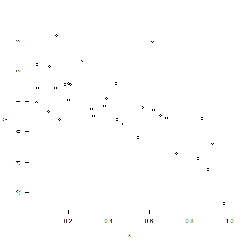

```r
plot(x, y)
```

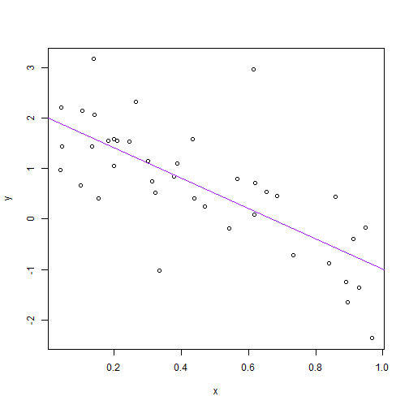

```r
plot(x, y)
abline(a, b, col="purple")
```

```r
dev.print(pdf, "practiceLine.pdf")
```

### Finding help (part 1)

`?plot`

`?abline`

### First script

- If you happy with how that plot looks (you can change lots of aspects but we won't right now), save the commands as a script.
  - Go into `History`
  - Highlight the lines you want
  - Click `To Source`
  - Save this as practiceLine.R
- Write yourself (or others) comments to explain what's going on by typing `#`

### Test your first script

- Clear out your workspace
  - rm(list=ls())
  - and/or restart R (Session -> restart R)
- Open your project
- Execute your practiceLine.R script
- Did you recreate everything?

### Importing data

- Download [this](http://www.stat.ubc.ca/%7Ejenny/notOcto/STAT545A/examples/gapminder/data/gapminderDataFiveYear.txt) test dataset
- Import into your project

```r
gDat <- read.delim(file="gapminder.5year.txt") #read.delim is a special case of read.table, there are many of these and they can make you life much easier.  Read the read.table help
```

- You can also read the file in directly from the website but this only works with very carefully curated files

```r
gDat <- read.table(file="http://www.stat.ubc.ca/~jenny/notOcto/STAT545A/examples/gapminder/data/gapminderDataFiveYear.txt", fill=T)
```

- What kid of object is gDat?

### Readings for Tomorrow

[Tidy Data, Wickham 2014](http://www.jstatsoft.org/v59/i10/paper)

[Data sharing, White, et.al. 2013](http://library.queensu.ca/ojs/index.php/IEE/article/view/4608/4898)